# Text clustering

Authors

Leonardo Savianne

Thomas Rietman

Angelos Papoutsis

Published

November 2, 2025

```python
# INSTALL REQS
# | echo: true
# Install dependencies from requirements.txt
import subprocess, sys

subprocess.check_call([sys.executable, "-m", "pip", "install", "-r", "requirements.txt"])
```

```
0
```

```python
import os
import re
import string
import session_info
from typing import Optional, Tuple, Literal, Any
from functools import partial
from collections import Counter

import numpy as np
import pandas as pd

import seaborn as sns
import matplotlib.pyplot as plt
from IPython.display import clear_output

from tqdm import tqdm

import inflect
import nltk
from nltk import pos_tag
from nltk.corpus import stopwords, wordnet
from nltk.tokenize import word_tokenize
from nltk.stem import WordNetLemmatizer
from nltk.stem.porter import PorterStemmer

from sklearn.feature_extraction.text import TfidfVectorizer, CountVectorizer
from sklearn.preprocessing import normalize
from sklearn.decomposition import TruncatedSVD, LatentDirichletAllocation, NMF


from sklearn.cluster import KMeans
from sklearn.mixture import GaussianMixture

from sklearn.metrics import (
    silhouette_score, davies_bouldin_score, calinski_harabasz_score,
    adjusted_rand_score, normalized_mutual_info_score,
    v_measure_score, fowlkes_mallows_score
)

from umap import UMAP
import ast
from wordcloud import WordCloud


nltk.download('punkt')
nltk.download('stopwords')
nltk.download('punkt_tab')
nltk.download('wordnet')
nltk.download('omw-1.4')
nltk.download('averaged_perceptron_tagger_eng')


df = pd.read_csv('dataset/imdb_text2vec.csv')
# regex
YEAR_RE = re.compile(r"\b((?:18|19|20)\d{2}|[1-9]0['’]?s)\b")
RATING_RE = re.compile(r'\b\d*(?:\.\d+)?\s*/\s*(?:5|10|100)\b')
NUM_RE = re.compile(r'\b\d+(\.\d+)?\b')
SPACES_RE = re.compile(r'\s*([?!.,]+(?:\s+[?!.,]+)*)\s*') #ciao,bella -> ciao, bella
HTML_RE = re.compile(r"<(?:\"[^\"]*\"['\"]*|'[^']*'['\"]*|[^'\">])+>")
# other
p = inflect.engine()
stemmer = PorterStemmer()
lemmatizer = WordNetLemmatizer()
# filter for charts and excels
qmd = True


def _convert_nums(text:str,
        mx_splt_num:int = 1) -> str:

    '''
    We can also convert the numbers into words.
    This can be done by using the inflect library.

    mx_num_split, we do not want conversions, like 100-> one hundred,
    so we set the maximum number of words
    '''

    # assign <RATING>
    text = re.sub(RATING_RE,'<RATING>',text)
    #assign <YEAR> for 80s,90's, 1990...
    text = re.sub(YEAR_RE,'<YEAR>',text)

    # convert numbers below a threshold to string
    temp_str = text.split()
    new_string = []

    for w in temp_str:

        n2w = p.number_to_words(w) # if not a number(e.g. dog) it returns 'zero'
        cond = (w.isdigit()) and (len(n2w.split())<=mx_splt_num)

        to_append = n2w if cond else w
        new_string.append(to_append)

    # Other Numbers become <NUM>
    text = re.sub(NUM_RE,'<NUM>',' '.join(new_string))

    return text


def _remove_simple(text:str) -> str:

    """Does simple cleaning of HTML, and no spaces after commas"""

    # remove html patterns

    text = re.sub(HTML_RE, '', text)

    # remove issues like: ciao,bella
    text = SPACES_RE.sub(lambda x: "{} ".format(x.group(1).replace(" ", "")), text)

    return text


def _remove_punct(text:str,
                  to_keep:Optional[str] = "") -> str:
    '''
    We remove punctuations so that we don't have different forms of the same word.

    '''
    punctuation = ''.join(ch for ch in string.punctuation if ch not in to_keep)
    translator = str.maketrans('', '', punctuation)

    return text.translate(translator)


def _remove_stopwords(text:str,
                      other_stopwords:list[str]|str = ['movie','film'],
                      to_keep:list[str]|str = None,
                      lst_output:bool=False) -> list[str]:

    '''
    Stopwords are words that do not contribute much to the meaning of a sentence
    hence they can be removed. The NLTK library has a set of
    stopwords and we can use these to remove stopwords from our text.
    '''

    stop_words = set(stopwords.words("english"))

    if other_stopwords:
        if isinstance(other_stopwords, str):
            stop_words.add(other_stopwords)
        else:
            stop_words.update(other_stopwords)

    if to_keep:
        if isinstance(to_keep, str):
            stop_words.discard(to_keep)
        else:
            stop_words.difference_update(to_keep)

    word_tokens = word_tokenize(text)
    clean = [w for w in word_tokens if not w.lower() in stop_words]
    return clean if lst_output else ' '.join(clean)


def _stem_words(text:list[str]|str,
                lst_output:bool=True) -> list[str]:
    '''
    Stemming is the process of getting the root form of a word.
    Stem or root is the part to which affixes like -ed, -ize, -de, -s, etc are added.
    The stem of a word is created by removing the prefix or suffix of a word.

    '''
    word_tokens = text if isinstance(text,list) else word_tokenize(text)
    stems = [stemmer.stem(word) for word in word_tokens]
    return stems if lst_output else ' '.join(stems)


def _lemma_words(text:str,
                 lst_output:bool=True) -> list[str]:
    '''
    Lemmatization is an NLP technique that reduces a word to its root form.
    This can be helpful for tasks such as text analysis and search as it
    allows us to compare words that are related but have different forms.

    combines pos_tagging with wordnet_pos for better lemma

    '''

    iterable = _pos_tagging(text)

    lemmas = [lemmatizer.lemmatize(w,_get_wordnet_pos(p)) for w, p in iterable]

    return lemmas if lst_output else ' '.join(lemmas)


def _pos_tagging(text):
    '''
    POS tagging is the process of assigning each word in a sentence its grammatical category,
    such as noun, verb, adjective or adverb. It helps machines understand the structure
    and meaning of text, enabling tasks like parsing, information extraction and text analysis.

    NNP: Proper noun
    NN: Noun (singular)
    VBZ: Verb (3rd person singular)
    CC: Conjunction


    '''
    word_tokens = word_tokenize(text)
    return pos_tag(word_tokens)


def _get_wordnet_pos(treebank_tag):

    '''
    Get wordnet positioning.
    StackOverFlow suggestion: https://stackoverflow.com/questions/15586721/wordnet-lemmatization-and-pos-tagging-in-python
    '''

    if treebank_tag.startswith('J'):
        return wordnet.ADJ
    elif treebank_tag.startswith('V'):
        return wordnet.VERB
    elif treebank_tag.startswith('N'):
        return wordnet.NOUN
    elif treebank_tag.startswith('R'):
        return wordnet.ADV
    else:
        return wordnet.NOUN  #default


def preprocess_df(df:pd.DataFrame
                  ) -> pd.DataFrame:
    '''
    Perform all cleanings on reviews

    '''
    # score_column
    df['score'] = df['id'].apply(lambda x: x.split('_')[-1])

    # 0.  x.lower().split() -> lower case and remove extra spaces,
    # also number conversion (see above)
    df['num_clean'] = df['review'].apply(lambda x: _convert_nums(" ".join(x.lower().split())))

    # 1 remove html and ciao,bella->ciao, bella
    df['first_l_cl'] = df['num_clean'].apply(lambda x: _remove_simple(x))

    # 2 remove punctuation
    df['sec_l_cl'] = df['first_l_cl'].apply(lambda x: _remove_punct(x))

    # 3 lemmas: is context dependent if we remove
    df['lemmas_pre_stop'] = df['sec_l_cl'].apply(lambda x: _lemma_words(x, lst_output=False))

    # 4 remove stopwords
    df['lemmas'] = df['lemmas_pre_stop'].apply(lambda x: _remove_stopwords(x,lst_output= True))

    return df
```

```python
if qmd:
    print('Loading Cleaned Data')
    cleaned = pd.read_csv('dataset/cleaned_df.csv')
else:
    cleaned = preprocess_df(df)
    cleaned.to_csv('dataset/cleaned_df.csv')


cleaned.head(15)
```

```
Loading Cleaned Data
```

|  | Unnamed: 0 | id | sentiment | review | score | num_clean | first_l_cl | sec_l_cl | lemmas_pre_stop | lemmas |
| --- | --- | --- | --- | --- | --- | --- | --- | --- | --- | --- |
| 0 | 0 | 5814_8 | 1 | With all this stuff going down at the moment w... | 8 | with all this stuff going down at the moment w... | with all this stuff going down at the moment w... | with all this stuff going down at the moment w... | with all this stuff go down at the moment with... | ['stuff', 'go', 'moment', 'mj', 'ive', 'start'... |
| 1 | 1 | 2381_9 | 1 | \"The Classic War of the Worlds\" by Timothy H... | 9 | \"the classic war of the worlds\" by timothy h... | \"the classic war of the worlds\" by timothy h... | the classic war of the worlds by timothy hines... | the classic war of the world by timothy hines ... | ['classic', 'war', 'world', 'timothy', 'hines'... |
| 2 | 2 | 7759_3 | 0 | The film starts with a manager (Nicholas Bell)... | 3 | the film starts with a manager (nicholas bell)... | the film starts with a manager (nicholas bell)... | the film starts with a manager nicholas bell g... | the film start with a manager nicholas bell gi... | ['start', 'manager', 'nicholas', 'bell', 'give... |
| 3 | 3 | 3630_4 | 0 | It must be assumed that those who praised this... | 4 | it must be assumed that those who praised this... | it must be assumed that those who praised this... | it must be assumed that those who praised this... | it must be assume that those who praise this f... | ['must', 'assume', 'praise', 'great', 'filmed'... |
| 4 | 4 | 9495_8 | 1 | Superbly trashy and wondrously unpretentious 8... | 8 | superbly trashy and wondrously unpretentious <... | superbly trashy and wondrously unpretentious ... | superbly trashy and wondrously unpretentious ... | superbly trashy and wondrously unpretentious e... | ['superbly', 'trashy', 'wondrously', 'unpreten... |
| 5 | 5 | 8196_8 | 1 | I dont know why people think this is such a ba... | 8 | i dont know why people think this is such a ba... | i dont know why people think this is such a ba... | i dont know why people think this is such a ba... | i dont know why people think this be such a ba... | ['dont', 'know', 'people', 'think', 'bad', 'ge... |
| 6 | 6 | 7166_2 | 0 | This movie could have been very good, but come... | 2 | this movie could have been very good, but come... | this movie could have been very good, but come... | this movie could have been very good but comes... | this movie could have be very good but come up... | ['could', 'good', 'come', 'way', 'short', 'che... |
| 7 | 7 | 10633_1 | 0 | I watched this video at a friend's house. I'm ... | 1 | i watched this video at a friend's house. i'm ... | i watched this video at a friend's house. i'm ... | i watched this video at a friends house im gla... | i watch this video at a friend house im glad i... | ['watch', 'video', 'friend', 'house', 'im', 'g... |
| 8 | 8 | 319_1 | 0 | A friend of mine bought this film for 1, and e... | 1 | a friend of mine bought this film for <NUM>, a... | a friend of mine bought this film for, and eve... | a friend of mine bought this film for and even... | a friend of mine bought this film for and even... | ['friend', 'mine', 'bought', 'even', 'grossly'... |
| 9 | 9 | 8713_10 | 1 | <br /><br />This movie is full of references. ... | 10 | <br /><br />this movie is full of references. ... | this movie is full of references. like \"mad m... | this movie is full of references like mad max ... | this movie be full of reference like mad max i... | ['full', 'reference', 'like', 'mad', 'max', 'i... |
| 10 | 10 | 2486_3 | 0 | What happens when an army of wetbacks, towelhe... | 3 | what happens when an army of wetbacks, towelhe... | what happens when an army of wetbacks, towelhe... | what happens when an army of wetbacks towelhea... | what happen when an army of wetback towelheads... | ['happen', 'army', 'wetback', 'towelheads', 'g... |
| 11 | 11 | 6811_10 | 1 | Although I generally do not like remakes belie... | 10 | although i generally do not like remakes belie... | although i generally do not like remakes belie... | although i generally do not like remakes belie... | although i generally do not like remake believ... | ['although', 'generally', 'like', 'remake', 'b... |
| 12 | 12 | 11744_9 | 1 | \"Mr. Harvey Lights a Candle\" is anchored by ... | 9 | \"mr. harvey lights a candle\" is anchored by ... | \"mr. harvey lights a candle\" is anchored by ... | mr harvey lights a candle is anchored by a bri... | mr harvey light a candle be anchor by a brilli... | ['mr', 'harvey', 'light', 'candle', 'anchor', ... |
| 13 | 13 | 7369_1 | 0 | I had a feeling that after \"Submerged\", this... | 1 | i had a feeling that after \"submerged\", this... | i had a feeling that after \"submerged\", this... | i had a feeling that after submerged this one ... | i have a feeling that after submerge this one ... | ['feeling', 'submerge', 'one', 'wouldnt', 'goo... |
| 14 | 14 | 12081_1 | 0 | note to George Litman, and others: the Mystery... | 1 | note to george litman, and others: the mystery... | note to george litman, and others: the mystery... | note to george litman and others the mystery s... | note to george litman and others the mystery s... | ['note', 'george', 'litman', 'others', 'myster... |

# Data Description

For this assignment we use a dataset of movie reviews from IMDB. We decided to clean the data up first before we give a nice overview of what we use. The explanantion of the cleaning will follow below. The only imporant thing to know is that the sentiment is either 0 or 1, with 1 being a review of 7 or higher and 0 being below that.

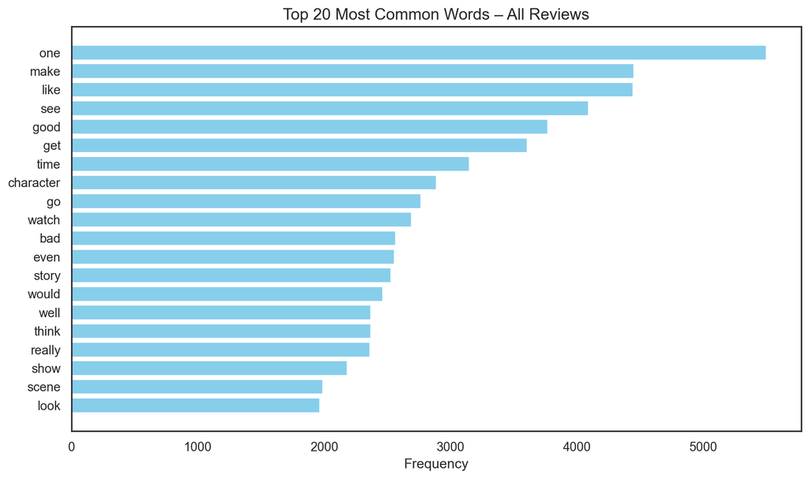

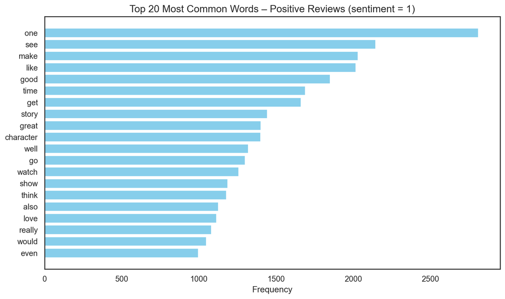

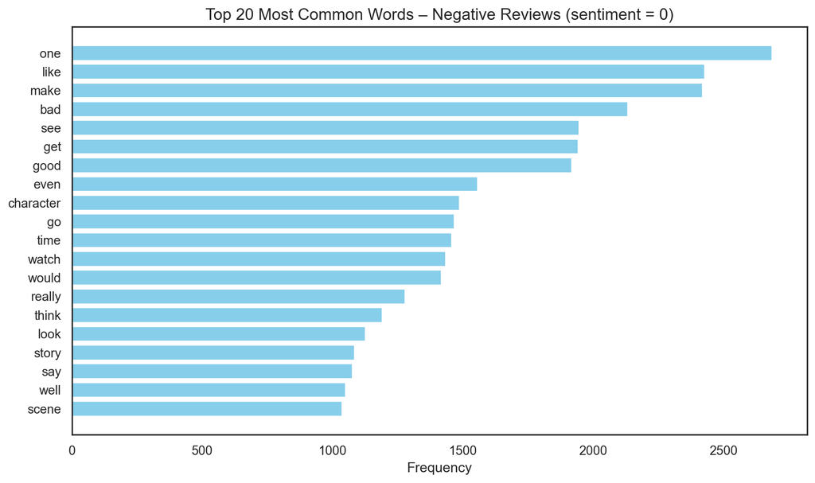

```python
# convert str list to list of strings
cleaned_lists = pd.DataFrame({
    'lemmas': cleaned['lemmas'].apply(
        lambda x: ast.literal_eval(x) if isinstance(x, str) else x
    ),
    'sentiment': cleaned['sentiment']
})


stop_words_custom = {"movie", "film"}

def get_word_counts(series):
    all_words = [word for lst in series for word in lst if word not in stop_words_custom]
    return Counter(all_words)
# --- Compute counts ---
all_counts = get_word_counts(cleaned_lists['lemmas'])
pos_counts = get_word_counts(cleaned_lists[cleaned_lists['sentiment'] == 1]['lemmas'])
neg_counts = get_word_counts(cleaned_lists[cleaned_lists['sentiment'] == 0]['lemmas'])

# ---  Helper function to plot top N words ---
def plot_top_words(counter, title, n=20):
    common = counter.most_common(n)
    words, counts = zip(*common)
    plt.figure(figsize=(10, 6))
    plt.barh(words[::-1], counts[::-1], color='skyblue')
    plt.title(title, fontsize=14)
    plt.xlabel('Frequency')
    plt.tight_layout()
    plt.show()

# ---  Plot all three ---
plot_top_words(all_counts, 'Top 20 Most Common Words – All Reviews')
plot_top_words(pos_counts, 'Top 20 Most Common Words – Positive Reviews (sentiment = 1)')
plot_top_words(neg_counts, 'Top 20 Most Common Words – Negative Reviews (sentiment = 0)')
```

These are the top 20 most common lemmatized words across all reviews and reviews with either a good or a bad sentiment. We can see that words like bad score way higher on the negative reviews. This is to be expected but good to see. A lot of words appear in both, these words dont necessarily indicate if something is bad or good.

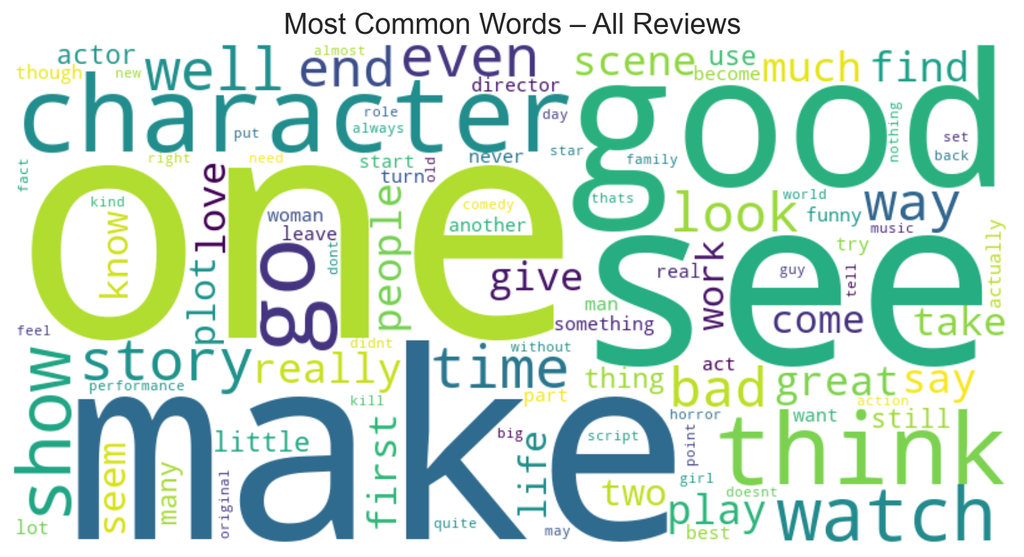

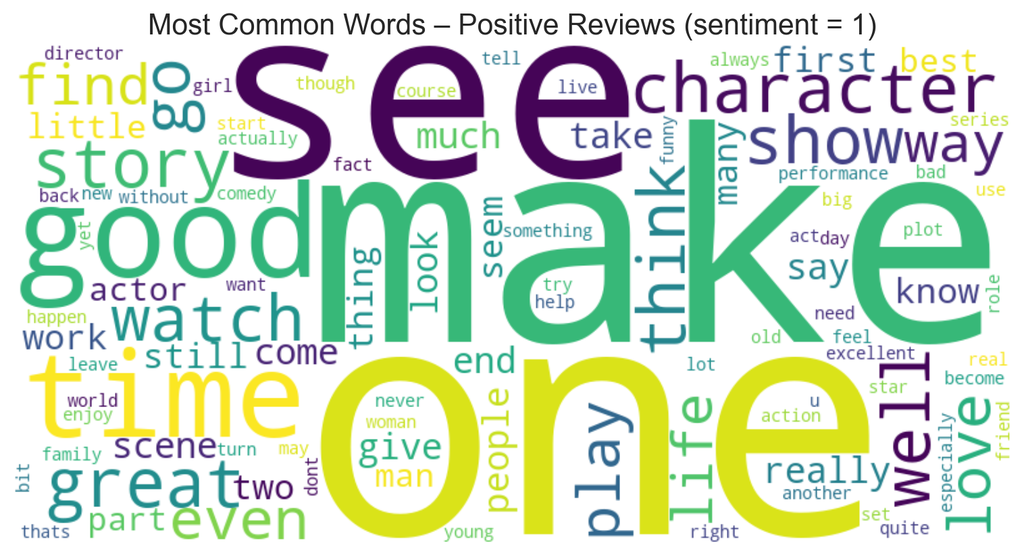

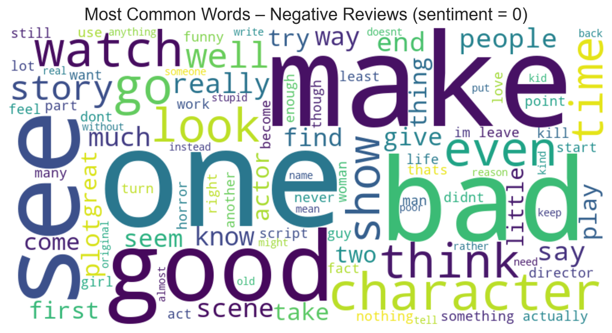

```python
all_text = ' '.join(
    word for lst in cleaned_lists['lemmas']
    for word in lst
    if word not in stop_words_custom
)

pos_text = ' '.join(
    word for lst in cleaned_lists[cleaned_lists['sentiment'] == 1]['lemmas']
    for word in lst
    if word not in stop_words_custom
)

neg_text = ' '.join(
    word for lst in cleaned_lists[cleaned_lists['sentiment'] == 0]['lemmas']
    for word in lst
    if word not in stop_words_custom
)

# --- Generate word clouds ---
def make_wordcloud(text, title, max_words=100):
    wc = WordCloud(
        width=800,
        height=400,
        background_color='white',
        max_words=max_words,
        colormap='viridis'
    ).generate(text)

    plt.figure(figsize=(10, 5))
    plt.imshow(wc, interpolation='bilinear')
    plt.axis('off')
    plt.title(title, fontsize=16)
    plt.show()

# --- Create and display ---
make_wordcloud(all_text, 'Most Common Words – All Reviews')
make_wordcloud(pos_text, 'Most Common Words – Positive Reviews (sentiment = 1)')
make_wordcloud(neg_text, 'Most Common Words – Negative Reviews (sentiment = 0)')
```

Here we have made wordclouds for the same groups as before. These include the top 100 words for each category with the bigger words being more common.

# Text pre-processing

Our function preprocess_df, picks up the main cleaning steps in the following order 1. We set to lower case and remove unnecessary blanks 2. we convert numbers to strings if below 100, ratings (e.g. 7.5/10,60/100) become < RATING > while expression of years (e.g. 80s/2000) become < YEAR >, while other numbers become < NUM > so that we do not loose information 3. Upon taking care of numbers, we do a simple clearning to fix some issues: such as html markers (e.g. <) and to add forgotten blanks after commas. 4. We can now remove the whole punctuations 5. We apply lemmatization. 6. We remove stopwords

The number cleaning part was done because we believe that numbers in reviews can have different meanings, for example a rating (e.g. 7.5/10) is very different from a year (e.g. 80s) or from a generic number (e.g. 3 actors). Thus we wanted to keep this information while avoiding to have too many different numbers that would not add value to our models.

We decided on removing some custom stopwords ourselves aswell. These are movie and film, this choice was made because we saw that they were influencing the results of our models intially, while they do not add any relevant information to the reviews. Since every review is about a movie/film, these words are not relevant for our classification task.

Another choice we made was to do the lemmatization before removing the stopwords, partly because some words mighr become stopwords only after lemmatization and partly because we wanted to keep the context of the words as much as possible before removing them, since lemmatization is context dependent.

# Text Representation

The _modelPreprocessing() function applies model-specific text vectorisation before training:

- Reviews were first tokenised and lemmatised, following the steps described above.
- For LDA we use CountVectorizer, while for other models we use IDF-TF matrix inputs. According to our searches in stackoverflow (See below for links), LDA models probabilities of word occurrences, whereas TF-IDF is a re-weighting scheme that breaks the probabilistic foundation, thefore Counter is more suited for the task. For both vectorizers, we assigned the max number of components of 50000, and we kept words that appear in at least 5 reviews (min_df), and removed words that appear in 90% of those (max_df). A brief description of the two preprocessing techniques:
  - Count Vectorizer: tokenizes the text along with performing very basic preprocessing. It removes the punctuation marks and converts all the words to lowercase. Therefore a vocabulary is formed. An encoded vector is returned with a length of the entire vocabulary and an integer count for the number of times each word appeared in the document.
  - TF-IDF Vectorizer: This is a statistical method evaluates how important a word is to a document in relation to a larger collection of documents. TF-IDF combines two components:
    1. Term Frequency (TF): Measures how often a word appears in a document. A higher frequency suggests greater importance. If a term appears frequently in a document, it is likely relevant to the document’s content.
    2. Inverse Document Frequency (IDF): Reduces the weight of common words across multiple documents while increasing the weight of rare words. If a term appears in fewer documents, it is more likely to be meaningful and specific.
- We do an additional step for VKM and GMM, that is the component reduction with SVDTruncated. We decided to not use PCA, as SVD seems to be much better with sparse dataset and text data represented as term-document matrices, and it is less computationally demanding. In our case we reduced to 200 components.

## Model fitting and storage

The dct_MLmodels() function trains each model for k=2 to k=10 clusters and stores results in a structured dictionary (dct_models). For each configuration, the function saves:

- the fitted model object,
- predicted cluster labels,
- the dense feature representation,
- ground-truth sentiment labels,
- for GMM also AIC and BIC, useful for comparing model complexity and goodness-of-fit.

```python
def _clusterSelection(model:Literal["LDA","NMF",'VKM', 'GMM'],
                      k:int = None,
                      rs_seed:int=1
                      ) -> Any:
    """
    Return the clustering model object and its Optuna parameter space.
    model: one of ['SKM', 'GMM', 'SPEC']
    """
    match model:
        case 'VKM':
            ml_model = KMeans(
                n_clusters=k,
                random_state=rs_seed,
                init='k-means++',
                n_init=10,
                max_iter=500
            )

        case 'GMM':
            ml_model = GaussianMixture(
                n_components=k,
                covariance_type='full',
                init_params='kmeans',
                max_iter = 300,
                random_state=rs_seed,
                verbose=False
            )

        case 'LDA':
            ml_model = LatentDirichletAllocation(
                n_components=k,
                random_state=rs_seed,
                learning_method='batch',
                learning_offset=10.0,
                max_iter=50,
                n_jobs=-1
            )

        case 'NMF':
            ml_model = NMF(
                n_components=k,
                init='nndsvda',
                solver='cd',
                beta_loss='frobenius',
                max_iter=2000,
                tol=1e-4,
                random_state=rs_seed
            )

    return ml_model


def _modelPreprocessing(df:pd.DataFrame,
                        model:str,
                        svd_comp:int=200,
                        max_features:int=50000,
                        min_df:float|int = 5, # keep the word if appears in at least 5 reviews
                        max_df:float|int = 0.9, # delete words that apper in 90% of the reviews
                        sd:int=1) -> Tuple[np.ndarray, np.ndarray]:
    """
    Data Preprocessing for the models, ensure right format and apply min_df and max_df
    - GMM, VKM: TFIDF + SVDtrucanted
    - NMF: TFIDF
    - LDA: Count Vectorizer

    return sentiment labels and model inputs

    """
    labels = df['sentiment'].to_numpy()
    labels10 = df['score'].to_numpy()

    in_text = df['lemmas'].apply(
        lambda x: " ".join(x) if isinstance(x, list)
        else x)

    vectorizer = TfidfVectorizer(
            max_features=max_features,
            stop_words='english',
            min_df=min_df,
            max_df=max_df
        )

    match model:
        case "GMM"|'VKM':
            tf_idf = vectorizer.fit_transform(in_text)
            reducer = TruncatedSVD(n_components=svd_comp, random_state=sd)
            x = reducer.fit_transform(tf_idf).astype(np.float32)

        case "NMF":
            x = vectorizer.fit_transform(in_text)

        case "LDA":
            count_vec = CountVectorizer(
                max_features=max_features,
                stop_words="english",
                min_df=min_df,
                max_df=max_df)
            x = count_vec.fit_transform(in_text)

    return x, labels, labels10


def dct_MLmodels(df: pd.DataFrame,
                 models: list[str] = ["LDA","NMF",'VKM','GMM'],
                 svd_comp: int = 200,
                 rs_seed: int = 1) -> dict:
    """
    Train all clustering models once per specified k and store results.
    Returns a dictionary with all fitted models, embeddings, and labels.
    """

    dct_models = {}

    for model in models:
        clear_output(wait=True)
        print(f"Training {model} model!\n")

        v, labels, labels10 = _modelPreprocessing(df, model, svd_comp=svd_comp)

        for k in range(2,11):
            ml_model = _clusterSelection(model, k, rs_seed=rs_seed)

            if model in ['LDA', 'NMF']:
                doc_topic = ml_model.fit_transform(v)
                preds = doc_topic.argmax(axis=1)
                vals_dense = normalize(doc_topic)

            else:
                preds = ml_model.fit_predict(v)
                if hasattr(v, "toarray"):
                    vals_dense = v.toarray()
                else:
                    vals_dense = v

            key = f"{model}_{k}"
            dct_models[key] = {
                "model": ml_model,
                "preds": preds,
                "vals": vals_dense,
                "labels": labels,
                "labels10": labels10,
                "aic": ml_model.aic(vals_dense) if model == 'GMM' else None,
                "bic":ml_model.bic(vals_dense) if model == 'GMM' else None
            }
    clear_output()
    return dct_models
```

# Text clustering

## Model selection

The _clusterSelection() function dynamically returns an instance of the selected clustering algorithm given a model name and a number of clusters.

We implemented the following models :

### K-Means (VKM)

Idea: Group similar documents together based on their word patterns.

#### How it works:

Each document is represented as a high-dimensional TF-IDF vector, which captures how important each word is to that document relative to the corpus. K-Means starts by selecting k random “centroids” (one per cluster).

#### Pros

- Fast, simple, and works well on large, sparse text data when using TF-IDF.
- Produces distinct, non-overlapping clusters.

#### Cons

- Assumes clusters are are cicrular if you would represent them in a graph and they are the same size.
- Not probabilistic, each document belongs to exactly one cluster.

### Gaussian Mixture Models (GMM)

Idea: Instead of assigning documents to one cluster, with GMM Each document partly belongs to several clusters.

#### How it works:

GMM assumes that the data are generated by k Gaussian distributions (each one corresponds to a cluster).

Each cluster has parameters:

- Mean vector (center)
- Covariance matrix (shape/volume)
- Mixing weight (how common the cluster is)

The algorithm uses the Expectation–Maximisation (EM) procedure:

- E-step: Compute the probability that each document belongs to each cluster.
- M-step: Update the Gaussian parameters to maximize the likelihood of the observed data.

Initialization is done using K-Means centroids to ensure stability.

#### Pros:

- Soft clustering: each document gets a probability of belonging to each cluster.
- Can model clusters of different shapes and densities (unlike K-Means).

#### Cons

- Computationally heavier than K-Means.
- Sensitive to initialization and covariance structure.
- Assumes data roughly follow a Gaussian shape (which may not be true for TF-IDF).

### Latent Dirichlet Allocation (LDA)

Idea: Finds topics in a collection of documents, like horror or comedy.

#### How it works:

LDA assumes a generative process:

- Each document has its own distribution over k latent topics.
- Each topic is a distribution over words.
- For each word in a document, a topic is chosen from the document’s topic distribution, and then a word is drawn from that topic’s word distribution.

Training (via variational inference or Gibbs sampling) estimates:

- The topic–word distributions
- The document–topic distributions

#### Pros:

- Produces human-interpretable topics.
- Handles polysemy (same word with multiple meanings) via topic mixtures.

#### Cons

- Requires raw counts, not TF-IDF.
- Sensitive to hyperparameters (α, β) and number of topics.

### Non-negative Matrix Factorisation (NMF)

Idea: Like LDA, it finds topics, but it uses more math instead of probabilities.

#### How it works:

Given a document–term matrix 𝑉 (size: documents × words):

𝑉≈𝑊×𝐻

𝑊: document–topic matrix (each row shows how much each topic contributes to the document) 𝐻: topic–term matrix (each column shows how much each word contributes to the topic) The factorisation is constrained so that all entries are non-negative, which encourages parts-based, interpretable representations.

Training is usually done by minimizing reconstruction error via iterative updates.

#### Pros:

- Produces interpretable topics similar to LDA but often simpler and faster.
- Works directly on TF-IDF features.
- Deterministic initializations make it stable and reproducible.

#### Cons

- Produces “soft” associations but not probabilistic ones.
- Can get stuck in local minima (hence long iteration limits help).

### Detour: Cosine Similarity

```python
def Clusters_Indicators(df:pd.DataFrame,
                ml_dct:dict,
                 models:list[str] = ["LDA","NMF",'VKM', 'GMM'],
                 sd:int = 1,
                 svd_comp:int=200,
                 labels10:bool = False
                 ) -> pd.DataFrame:

    """
    Test Models three selected models for 5 to 10 number of clusters.
    Return a pandas df with outputs
    """

    res_dct = {
        'model':[],
        'n_clusters':[],
        'sil':[],
        'dbi':[],
        'ari':[],
        'chi':[],
        'nmi': [],
        'vmeasure': [],
        'fmi': [],
        'aic':[],
        'bic':[]}

    for model in models:
        v, _, _ = _modelPreprocessing(df, model, svd_comp=svd_comp)
        clear_output()
        print(f'Working on {model}')
        for n_clusters in range(2,11):

            model_ref = ml_dct[f'{model}_{n_clusters}']
            vals_dense = model_ref['vals']
            labels = model_ref['labels'] if not labels10 else model_ref['labels10']
            preds = model_ref['preds']
            aic = model_ref['aic']
            bic = model_ref['bic']

            res_dct['model'].append(model)
            res_dct['n_clusters'].append(n_clusters)
            res_dct['sil'].append(silhouette_score(v, preds, metric='cosine',random_state=sd)) #internal
            res_dct['dbi'].append(davies_bouldin_score(vals_dense, preds)) #internal
            res_dct['ari'].append(adjusted_rand_score(labels, preds)) #external

            res_dct['chi'].append(calinski_harabasz_score(vals_dense, preds)) #internal
            res_dct['nmi'].append(normalized_mutual_info_score(labels, preds)) # external
            res_dct['vmeasure'].append(v_measure_score(labels, preds)) #external
            res_dct['fmi'].append(fowlkes_mallows_score(labels, preds)) #external
            #gmm
            res_dct['aic'].append(aic)
            res_dct['bic'].append(bic)

    return pd.DataFrame(res_dct)


def comparison_charts(df:pd.DataFrame,
                      indicators: list[str]=['sil','dbi','chi','ari','nmi','fmi'], #only most relevant
                      labels10:bool = False)->None:

    """
    Create a 2x3 grid of subplots comparing models across validation indicators.
    Each subplot shows scores for all models as a function of n_clusters.
    The metrics to plot (3 internal + 3 external)
    """


    sns.set_context("notebook")
    sns.set_style("white")


    fig, axes = plt.subplots(2 if len(indicators)>3 else 1,
                             3, figsize=(12, 6), sharex=True)
    axes = axes.flatten()

    model_palette = sns.color_palette("deep", n_colors=df['model'].nunique())
    hue_order = sorted(df['model'].unique())

    handles, labels = None, None # init

    for i, ind in enumerate(indicators):
        ax = axes[i]

        if ind not in df.columns:
            ax.set_visible(False)
            continue

        plot = sns.lineplot(
            data=df,
            x='n_clusters',
            y=ind,
            hue='model',
            hue_order=hue_order,
            marker='o',
            linewidth=1.3,
            ax=ax,
            palette=model_palette
        )

        if handles is None:
            handles, labels = plot.get_legend_handles_labels()

        leg = ax.get_legend()
        if leg:
            leg.remove()

        ax.set_title(ind.upper(), fontsize=9, weight='bold', pad=3)
        ax.set_xlabel('')
        ax.set_ylabel('')
        ax.tick_params(labelsize=8)
        ax.spines[['top','right']].set_visible(False)
        ax.grid(False)

        if ind == 'dbi':
            ax.invert_yaxis()

    if handles and labels:
        fig.legend(
            handles, labels,
            loc='upper center',
            ncol=len(hue_order),
            frameon=False,
            fontsize=9,
            handlelength=2.0
        )

    plt.subplots_adjust(wspace=0.3, hspace=0.25, top=0.88)
    plt.savefig(f"charts/indicators_svd{'_l10' if labels10 else ''}.png")
    plt.show()




def cluster_charts(ml_dct:dict,
                   models: list[str] = ["LDA","NMF",'VKM','GMM'],
                   umap_metric:Literal['cosine','euclidean','manhattan'] = 'euclidean',
                   sd: int = 1) -> None:
    """
    Visualize clusters (k=5 and k=10) for each model in a 2x6 grid.

    Each subplot shows a 2D UMAP projection of the clustered space.
    Works for dense and sparse data (TF-IDF, embeddings, etc.)
    """

    sns.set_context("notebook")
    sns.set_style("white")
    fig, axes = plt.subplots(3, len(models), figsize=(3.5*len(models), 7))

    for col, model in enumerate(models):
        clear_output()
        for idx, n_clusters in enumerate([2, 5, 10]):

            model_ref = ml_dct[f'{model}_{n_clusters}']
            vals_dense = model_ref['vals']
            labels = model_ref['labels']
            preds = model_ref['preds']

            ari = adjusted_rand_score(labels, preds)
            nmi = normalized_mutual_info_score(labels, preds)

            reducer = UMAP(
                n_neighbors=15,
                n_components=2,
                metric=umap_metric,
                random_state=sd,
                n_jobs=-1
            )

            X_2d = reducer.fit_transform(vals_dense)

            ax = axes[idx, col]

            sns.scatterplot(
                    x=X_2d[:, 0], y=X_2d[:, 1],
                    hue=preds,
                    palette='tab10',
                    s=10, alpha=0.8, linewidth=0,
                    ax=ax, legend=False
                )

            ax.set_title(f"{model} | k={n_clusters}\nARI={round(ari,3)}, NMI={round(nmi,3)}",
             fontsize=9, weight='bold', pad=3)
            ax.set_xticks([]); ax.set_yticks([])
            ax.spines[['top', 'right', 'bottom', 'left']].set_visible(False)

    plt.suptitle(f"Cluster Visualization (UMAP 2D {umap_metric.title()} Projection)",
                 fontsize=12, weight='bold', y=0.98)
    plt.tight_layout(rect=[0, 0, 1, 0.96])
    plt.savefig(f'charts/clusters_svd{umap_metric}.png')
    plt.show()
```